# RQ1_dataPrep

Kamau Lindhardt, lbk125

26/7/2022

Research Question 1

1. What are the current themes of knowledge abundance and scarcity as related to temperate silvoarable agroforestry systems?
1. Which silvoarable agroforestry systems, are highly represented and which a poorly represented?
2. Which crop and tree species are highly represented and which a poorly represented?
3. Which biodiversity and ecosystem services are highly represented and which a poorly represented in different systems?

Packages to be installed first

```r
# install.packages("pacman")
```

Loading packages and libraries

```r
suppressWarnings({

# Applying the p_load function to load multiple add-on packages in one line of code.

pacman::p_load(tidyverse,
               readxl,
               ggplot2,
               ggpubr,
               ggthemes,
               ggsci,
               wesanderson,    # for colour palettes
               colorspace,     # for colour palettes
               gt,             # for beautiful tables
               DT,
               cowplot)        # for making multi-plots side by side

  })
```

Loading main database

```r
suppressWarnings({

database <- read_excel("DATA/DATABASE_2.0.xlsx",
    sheet = "MAIN_DATABASE_2.0") %>%
    filter(INCLUDED == TRUE)

})
# View(database)
```

Defining number of independent studies and number of observations based on individual study sites

```r
n_independent_studies <- database %>%
  count(ID.P) %>%
  nrow()

n_individual_study_sites <- nrow(database)
```

Colour and design elements

```r
# scales::show_col(ipsum_pal()(9))

# Define colour palette for a single colors
my_col_single = sequential_hcl(1, palette = "Terrain 2")

my_cols_pal_four <-  qualitative_hcl(4, palette = "Dynamic")
#wes_palette("Zissou1", 4, type = "continuous")

my_cols_pal_six <- qualitative_hcl(6, palette = "Dynamic")
#wes_palette("Zissou1", 6, type = "continuous")

my_cols_pal_100 <- diverging_hcl(100, palette = "Green-Orange")
#wes_palette("Zissou1", 100, type = "continuous")
```

Function that sets the size of the figure margins

```r
# Writing a small function that sets the size of the margin based on the number of characters in the leftmost x-axis category value.
# the function makes use of the number of characters in the dataset$column and adds an additional number of space based on what is specified in the function

margin_spacer <- function(x) {
  # where x is the column in your dataset
  left_length <- nchar(levels(factor(x)))[1]
  if (left_length > 8) {
    return((left_length - 8) * 10) # additional figure margin space is here set to 10, if the x-axis category is having > 8 characters.
  }
  else
    return(0)
}
```

# RQ1: What are the current themes of knowledge abundance and scarcity as related to temperate silvoarable agroforestry systems?

## RQ1.a - Which silvoarable agroforestry systems, are highly represented and which a poorly represented?

**Silvoarable system traits (agroforestry system types) represented in the database**

*Preparing dataset*

```r
system.trait.data <- database %>%
  filter(INCLUDED == TRUE) %>%

    dplyr::mutate(ST.TYPE = case_when(
      str_detect(ST.TYPE, "RBS") ~ "Mixed and other systems",
      str_detect(ST.TYPE, "SHB") ~ "Mixed and other systems",
      str_detect(ST.TYPE, "MIXED") ~ "Mixed and other systems",
      str_detect(ST.TYPE, "TIMBER.ARABLE") ~ "Timber - Arable",
      str_detect(ST.TYPE, "BIOMASS.ARABLE") ~ "Biomass - Arable",
      str_detect(ST.TYPE, "NUT.ARABLE") ~ "Nut - Arable",
      str_detect(ST.TYPE, "FRUIT.ARABLE") ~ "Fruit - Arable",
      TRUE ~ as.character(as.character(ST.TYPE)))) %>%

  group_by(ST.TYPE) %>%
  summarise(count = n()) %>%
  mutate(pct = (count/sum(count))) %>%
  arrange(desc(-count)) %>%
  #summarise(count = sum(count)) %>%
  # filter(ST.TYPE != "NA")
  # Order factor levels by number, putting "Other" to end
  # Order factor levels by number, putting "NA" to next to end
  dplyr::mutate(ST.TYPE = forcats::fct_rev(forcats::fct_inorder(ST.TYPE)),
                ST.TYPE = forcats::fct_relevel(ST.TYPE, "NA", after = 5))
  #  dplyr::mutate(ST.TYPE = forcats::fct_rev(forcats::fct_inorder(ST.TYPE)),
  #              ST.TYPE = forcats::fct_relevel(ST.TYPE, "Mixed and other systems", after = 4))

# Checking that the reordering worked
levels(system.trait.data$ST.TYPE)
```

```
## [1] "Timber - Arable"         "Mixed and other systems"
## [3] "Biomass - Arable"        "Nut - Arable"
## [5] "Fruit - Arable"          "NA"
```

Barplot of silvoarable system traits

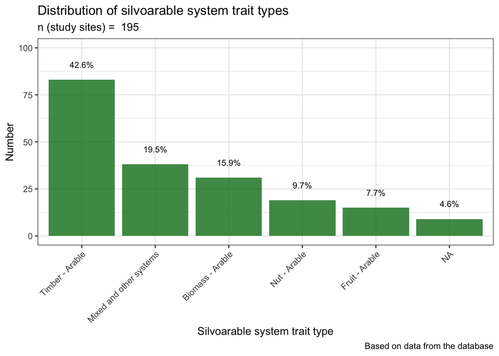

```r
ggplot(data = system.trait.data,
       aes(x = ST.TYPE,
           y = count)) +
  geom_bar(stat = "identity",
           fill = my_col_single,
           alpha = 0.8) +
  geom_text(aes(label=paste0(round(pct*100, 1),"%")), size=3, vjust = -2) +
  labs(x = "Silvoarable system trait type",
       y = "Number") +
  theme_bw() +
  theme(axis.text.x = element_text(angle = 45, hjust=1), legend.position = "none")  +
  ylim(c(0, 100)) +
  labs(title = "Distribution of silvoarable system trait types",
       subtitle = paste("n (study sites) = ", n_individual_study_sites),
       caption = paste("Based on data from the database"),
       x = "Silvoarable system trait type")
```

**Spatial arrangements (tree density, alley inter and intra row distance)**

*Preparing dataset*

```r
spatial.arrange.data <- database %>%
  filter(INCLUDED == TRUE) %>%

  select(ID.P, ID.S,
         CA.DIST.INTERROW, CA.DIST.INTERROW.MIN, CA.DIST.INTERROW.MAX,
         CA.DIST.INTRAROW) %>%
  mutate_if(is.character, as.numeric) %>%
  # where there is no information in the single value interrow distance, then use the mean value of interrow min and interrow max
  rowwise() %>%
  mutate(avr_interrow = mean(c(CA.DIST.INTERROW.MIN, CA.DIST.INTERROW.MAX), na.rm = FALSE))
# mutate(CA.DIST.INTERROW = ifelse(CA.DIST.INTERROW == "NA", avr_interrow, CA.DIST.INTERROW), .keep = "all")

# Using base R commands
# Duplicate data
  spatial.arrange.data_new <- spatial.arrange.data
# Replace NA values
spatial.arrange.data_new$CA.DIST.INTERROW[is.na(spatial.arrange.data_new$CA.DIST.INTERROW)] <-
  spatial.arrange.data_new$avr_interrow[is.na(spatial.arrange.data_new$CA.DIST.INTERROW)]

# Renaming to original
spatial.arrange.data <- spatial.arrange.data_new
```

Histogram of the interrow distance distribution

```r
interrow <-
  spatial.arrange.data %>%
  filter(CA.DIST.INTERROW != "NA")

overall_mean_interrow <- mean(interrow$CA.DIST.INTERROW)

#Plotting histogram and desity plot using the cowplot function

# 1. Create the histogram plot
p_histogram <-
  spatial.arrange.data %>%
# Add the density curve on the same axis
gghistogram(
  x = "CA.DIST.INTERROW", y = "..count..",
  add = "mean", col = "black", rug = TRUE,
  fill = my_col_single,
  alpha = 0.8,
  binwidth = 5,
  add_density = FALSE
  ) +
  scale_x_continuous(breaks = scales::pretty_breaks(n = 10)) +
 # scale_y_continuous(breaks = scales::pretty_breaks(n = 10)) +
  ylim(c(0, 30)) +
  annotate("text",                        # Add text for mean
           x = overall_mean_interrow * 2,
           y = overall_mean_interrow * 1,
           label = paste("Mean =", overall_mean_interrow),
           col = my_col_single,
           size = 4) +
  labs(title = "Distribution of interrow distances for silvoarable alley cropping systems",
       subtitle = paste("n (study sites) = ", n_individual_study_sites),
       caption = paste("Based on data from the database"),
       x = "Alley interrow distance (m)",
       y = "Number of sites having a given interrow distance")

# 2. Create the density plot with y-axis on the right
# Remove x axis elements
p_density <-
  spatial.arrange.data %>%
  ggdensity(
  x = "CA.DIST.INTERROW",
  colour = my_col_single,
  alpha = 0
) +
  scale_y_continuous(expand = expansion(mult = c(0, 0.2)), position = "right")  +
  theme_half_open(11, rel_small = 1) +
  rremove("x.axis")+
  rremove("xlab") +
  rremove("x.text") +
  rremove("x.ticks") +
  rremove("legend") +
  labs(y = "Density distribution of a given interrow distance")

# 3. Align the two plots and then overlay them.
aligned_plots <- align_plots(p_histogram, p_density, align = "hv", axis = "tblr")

histodensity.spatial.arrangements <-
  ggdraw(aligned_plots[[1]]) + draw_plot(aligned_plots[[2]])
```

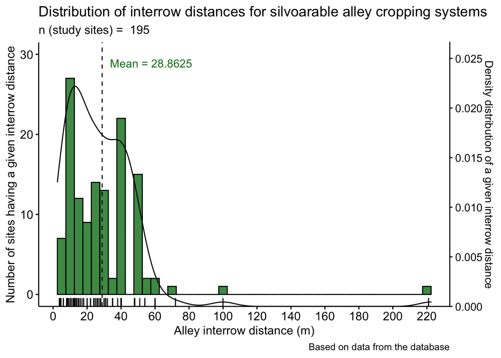

```r
histodensity.spatial.arrangements
```

## RQ1.b - Which crop and tree species are highly represented and which a poorly represented?

**Crop species groups represented in the database**

Generating broad categories of crop species - based on broad output product based on FAO, 2019. FAOSTAT database. http://www.fao.org/faostat/en/#data.

*Preparing dataset*

```r
crops.data <-
  read_excel("DATA/DATABASE_2.0.xlsx",
    sheet = "CROP_SPECIES") %>%
  # Generating broad categories of crop species - based on broad output product
  # based on FAO, 2019. FAOSTAT database. http://www.fao.org/faostat/en/#data.
    mutate(CROP.OUTPUT.GROUP = case_when(str_detect(CROP.SPECIES, "Triticum") ~ "CEREALS CROPS",
                                         str_detect(CROP.SPECIES, "Zea") ~ "CEREALS CROPS",
                                         str_detect(CROP.SPECIES, "Hordeum") ~ "CEREALS CROPS",
                                         str_detect(CROP.SPECIES, "Secale") ~ "CEREALS CROPS",
                                         str_detect(CROP.SPECIES, "Avena") ~ "CEREALS CROPS",
                                         str_detect(CROP.SPECIES, "Sorghum") ~ "CEREALS CROPS",
                                         str_detect(CROP.SPECIES, "Fagopyrum") ~ "CEREALS CROPS",

                                         str_detect(CROP.SPECIES, "Glycine") ~ "PULSES CROPS",
                                         str_detect(CROP.SPECIES, "Pisum") ~ "PULSES CROPS",
                                         str_detect(CROP.SPECIES, "Cicer") ~ "PULSES CROPS",
                                         str_detect(CROP.SPECIES, "Lupinus") ~ "PULSES CROPS",

                                         str_detect(CROP.SPECIES, "Beta") ~ "SUGAR CROPS",

                                         str_detect(CROP.SPECIES, "Cucurbita") ~ "VEGETABLES CROPS",
                                         str_detect(CROP.SPECIES, "UNSPECIFIED.VEGETABLES") ~ "VEGETABLES CROPS",
                                         str_detect(CROP.SPECIES, "Asparagus") ~ "VEGETABLES CROPS",
                                         str_detect(CROP.SPECIES, "Brassica oleracea") ~ "VEGETABLES CROPS",
                                         str_detect(CROP.SPECIES, "Capsicum") ~ "VEGETABLES CROPS",
                                         str_detect(CROP.SPECIES, "Citrullus") ~ "VEGETABLES CROPS",
                                         str_detect(CROP.SPECIES, "Cucumis") ~ "VEGETABLES CROPS",
                                         str_detect(CROP.SPECIES, "Lactuca") ~ "VEGETABLES CROPS",
                                         str_detect(CROP.SPECIES, "Solanum lycopersicum") ~ "VEGETABLES CROPS",

                                         str_detect(CROP.SPECIES, "Brassica napus subsp. Napus") ~ "OIL CROPS",
                                         str_detect(CROP.SPECIES, "Helianthus") ~ "OIL CROPS",
                                         str_detect(CROP.SPECIES, "Sinapsis") ~ "OIL CROPS",
                                         str_detect(CROP.SPECIES, "Brassica alba") ~ "OIL CROPS",

                                         str_detect(CROP.SPECIES, "Ribes") ~ "FRUIT CROPS",
                                         str_detect(CROP.SPECIES, "Rubus") ~ "FRUIT CROPS",
                                         str_detect(CROP.SPECIES, "Aronia") ~ "FRUIT CROPS",
                                         str_detect(CROP.SPECIES, "Fragaria") ~ "FRUIT CROPS",

                                         str_detect(CROP.SPECIES, "Solanum tuberosum") ~ "ROOTS AND TUBER CROPS",

                                         str_detect(CROP.SPECIES, "HERBS") ~ "OTHER CROPS FOR HUMAN CONS.",

                                         str_detect(CROP.SPECIES, "Lolium") ~ "GRASSES AND CROP ROTATION-SPECIFIC CROPS",
                                         str_detect(CROP.SPECIES, "Vicia") ~ "GRASSES AND CROP ROTATION-SPECIFIC CROPS",
                                         str_detect(CROP.SPECIES, "HAY.FODDER") ~ "GRASSES AND CROP ROTATION-SPECIFIC CROPS",
                                         str_detect(CROP.SPECIES, "Poa") ~ "GRASSES AND CROP ROTATION-SPECIFIC CROPS",
                                         str_detect(CROP.SPECIES, "UNSPECIFIED.CLOVERLAY") ~ "GRASSES AND CROP ROTATION-SPECIFIC CROPS",
                                         str_detect(CROP.SPECIES, "Festuca") ~ "GRASSES AND CROP ROTATION-SPECIFIC CROPS",
                                         str_detect(CROP.SPECIES, "Medicago") ~ "GRASSES AND CROP ROTATION-SPECIFIC CROPS",
                                         str_detect(CROP.SPECIES, "Panicum") ~ "GRASSES AND CROP ROTATION-SPECIFIC CROPS"
                                         )) %>%
  group_by(CROP.OUTPUT.GROUP) %>%
  summarise(count = n()) %>%
  mutate(pct = (count/sum(count))) %>%
  arrange(desc(-count)) %>%
  filter(CROP.OUTPUT.GROUP != "NA")

# View(database)
```

Print crop group data

```r
# colnames is a character vector of length 5, and we replace it
datatable(head(crops.data, 10),
          colnames = c('Aggregated crop group', 'Number of records', 'Proportions'),
          options = list(order = list(list(2, 'desc'))))
```

|  | Aggregated crop group | Number of records | Proportions |
| --- | --- | --- | --- |
| 1 | OTHER CROPS FOR HUMAN CONS. | 1 | 0.00212314225053079 |
| 2 | SUGAR CROPS | 4 | 0.00849256900212314 |
| 3 | VEGETABLES CROPS | 13 | 0.0276008492569002 |
| 4 | ROOTS AND TUBER CROPS | 21 | 0.0445859872611465 |
| 5 | PULSES CROPS | 29 | 0.0615711252653928 |
| 6 | GRASSES AND CROP ROTATION-SPECIFIC CROPS | 39 | 0.0828025477707006 |
| 7 | OIL CROPS | 80 | 0.169851380042463 |
| 8 | CEREALS CROPS | 227 | 0.481953290870488 |

Barplot of annual crop group distribution

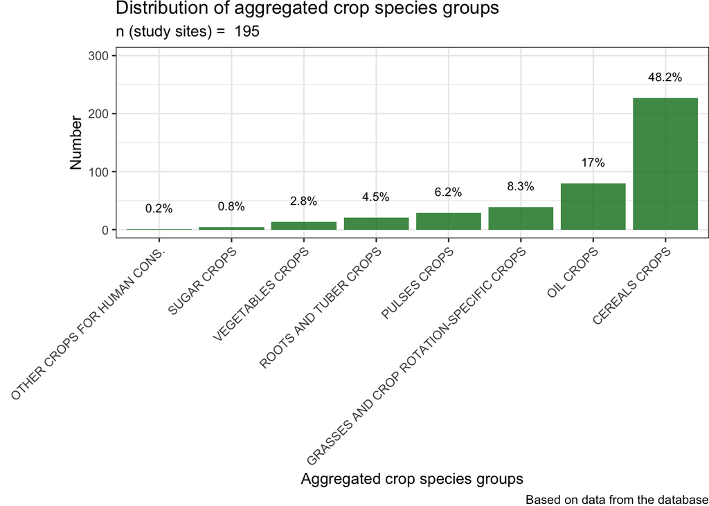

```r
ggplot(data = crops.data,
       aes(x = reorder(CROP.OUTPUT.GROUP, count), y = count)) +
  geom_bar(stat = "identity",
           fill = my_col_single,
           alpha = 0.8) +
  geom_text(aes(label = paste0(round(pct*100, 1), "%")), size = 3, vjust = -2) +
  labs(x = "Crop species",
       y = "Number") +
  theme_bw() +
  theme(axis.text.x = element_text(angle = 45, hjust = 1), legend.position = "none",
        plot.margin = margin(l = 0 + margin_spacer(crops.data$CROP.OUTPUT.GROUP)))  +
  ylim(c(0, 300)) +
  labs(title = "Distribution of aggregated crop species groups",
       subtitle = paste("n (study sites) = ", n_individual_study_sites),
       caption = paste("Based on data from the database"),
       x = "Aggregated crop species groups")
```

**Tree species represented in the database**

*Preparing dataset*

```r
suppressWarnings({

trees.data <-
  read_excel("DATA/DATABASE_2.0.xlsx",
    sheet = "TREE_SPECIES") %>%
  # Generating broad categories of tree species - based on families, genus and hybrids
    separate(TREE.SPECIES, c("TREE.FAMILY.GROUP", "TREE.GENUS.GROUP"), "^\\S*\\K\\s+", remove = FALSE) %>%
    separate(TREE.GENUS.GROUP, c("TREE.HYBRID.SPEC.1", "TREE.HYBRID.SPEC.2"), "^\\S*\\K\\s+", remove = FALSE) %>%

    dplyr::mutate(TREE.FAMILY.GROUP = case_when(
      str_detect(TREE.FAMILY.GROUP, '(?<![:alpha:])UNSPECIFIED(?![:alpha:])') ~ 'Unspecified trees',
      TRUE ~ as.character(as.character(TREE.FAMILY.GROUP)))) %>%
  # Grouping and preparing the trees species group data for plotting
  group_by(TREE.FAMILY.GROUP) %>%
  summarise(count = n()) %>%
  group_by(TREE.FAMILY.GROUP = replace(TREE.FAMILY.GROUP, count < 5, "Other species")) %>%
  summarise(count = sum(count)) %>%
  mutate(pct = (count/sum(count))) %>%
  filter(TREE.FAMILY.GROUP != "NA") %>%
  arrange(desc(-count)) %>%
  ## order factor levels by number, put "Other" to end
  dplyr::mutate(TREE.FAMILY.GROUP = forcats::fct_rev(forcats::fct_inorder(TREE.FAMILY.GROUP)),
                TREE.FAMILY.GROUP = forcats::fct_relevel(TREE.FAMILY.GROUP, "Other species", after = 15))

# Checking that the reordering worked
levels(trees.data$TREE.FAMILY.GROUP)

})
```

```
##  [1] "Populus"           "Juglans"           "Quercus"
##  [4] "Prunus"            "Acer"              "Fraxinus"
##  [7] "Sorbus"            "Salix"             "Robinia"
## [10] "Pinus"             "Malus"             "Corylus"
## [13] "Unspecified trees" "Pyrus"             "Other species"
```

Print tree species group data

```r
# colnames is a character vector of length 5, and we replace it
datatable(head(trees.data, 15),
          colnames = c('Aggregated by family (tree species group)', 'Number of records', 'Proportions'),
          options = list(order = list(list(2, 'desc'))))
```

|  | Aggregated by family (tree species group) | Number of records | Proportions |
| --- | --- | --- | --- |
| 1 | Pyrus | 5 | 0.0141643059490085 |
| 2 | Unspecified trees | 6 | 0.0169971671388102 |
| 3 | Corylus | 7 | 0.0198300283286119 |
| 4 | Malus | 7 | 0.0198300283286119 |
| 5 | Pinus | 8 | 0.0226628895184136 |
| 6 | Robinia | 9 | 0.0254957507082153 |
| 7 | Salix | 9 | 0.0254957507082153 |
| 8 | Sorbus | 12 | 0.0339943342776204 |
| 9 | Fraxinus | 15 | 0.0424929178470255 |
| 10 | Acer | 16 | 0.0453257790368272 |

[output cut: 5 more lines]

Barplot of tree species group distribution

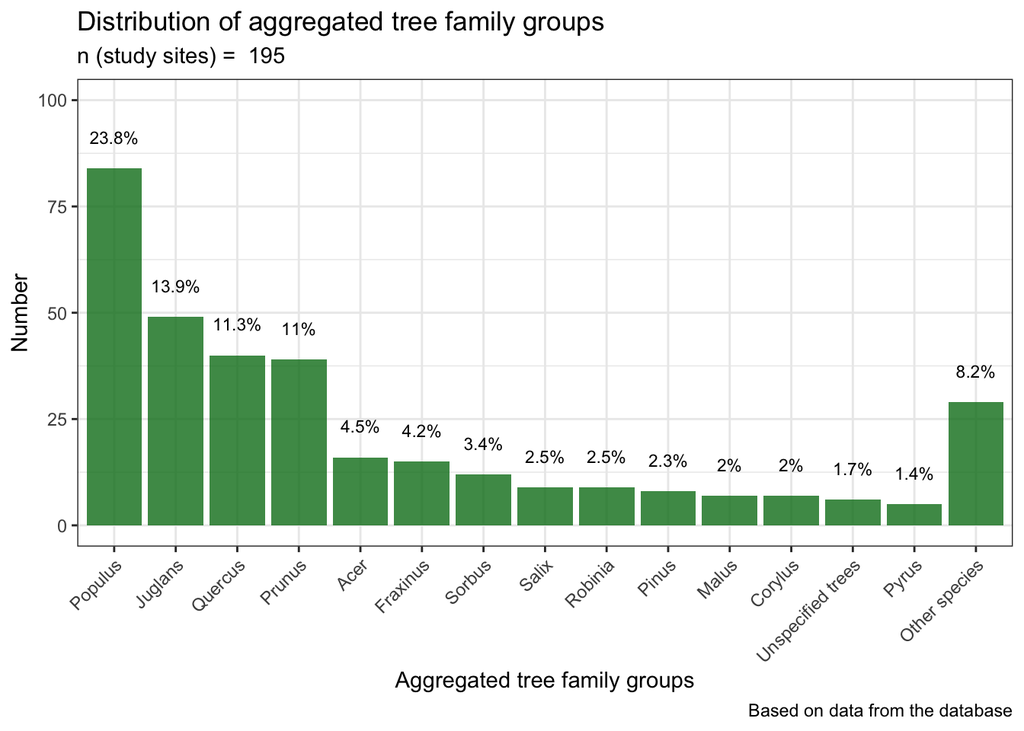

```r
ggplot(data = trees.data,
       aes(x = TREE.FAMILY.GROUP,
           y = count)) +
  geom_bar(stat = "identity",
           fill = my_col_single,
           alpha = 0.8) +
  geom_text(aes(label = paste0(round(pct*100, 1), "%")), size = 3, vjust = -2) +
  labs(x = "Tree species",
       y = "Number") +
  theme_bw() +
  theme(axis.text.x = element_text(angle = 45, hjust = 1), legend.position = "none")  +
  ylim(c(0, 100)) +
  labs(title = "Distribution of aggregated tree family groups",
       subtitle = paste("n (study sites) = ", n_individual_study_sites),
       caption = paste("Based on data from the database"),
       x = "Aggregated tree family groups")
```

## RQ1.c - Which biodiversity and ecosystem services are highly represented and which a poorly represented in different systems?

**Biodiversity indicators - distribution and abundance**

*Preparing dataset*

```r
biodiversity.data <-
  database %>%
  filter(INCLUDED == TRUE) %>%
  # selecting Biodiversity columns
  select(ID.P, ID.S, #ST.TYPE, MANAGEMENT
         starts_with("BD")) %>%
  mutate(across(matches("BD"), as.logical)) %>%
  mutate_all(~replace_na(., 0)) %>%                   # <- Including NA's as 0 (FALSE)
  mutate_if(is.logical, as.numeric)

# sum the data using apply & use this for beautiful barplot
biodiversity.sum.data <-
  data.frame(value = apply(biodiversity.data, MARGIN = 2, FUN = sum))


biodiversity.sum.data$key = rownames(biodiversity.sum.data)

biodiversity.plot.data <-
biodiversity.sum.data %>%
  rename(count = value,
         BD.SUB.INDICATORS =  key) %>%
  filter(BD.SUB.INDICATORS == "BD.SUB.FLORA" |
         BD.SUB.INDICATORS == "BD.SUB.FAUNAMACRO" |
         BD.SUB.INDICATORS == "BD.SUB.FLORAMICRO" |
         BD.SUB.INDICATORS == "BD.SUB.FUNGI" |
         BD.SUB.INDICATORS == "BD.SUB.BACTERIA" |
         BD.SUB.INDICATORS == "BD.SUB.SOILFAUNA") %>%
    # grouping of flora and fauna categories according to the defined data structures and data analysis framework
  mutate(BD.GROUPS = case_when(str_detect(BD.SUB.INDICATORS, "BD.SUB.FLORA") ~ "FLORA",
                               str_detect(BD.SUB.INDICATORS, "BD.SUB.FLORA") ~ "FLORA",

                               str_detect(BD.SUB.INDICATORS, "BD.SUB.FAUNAMACRO") ~ "FAUNA",
                               str_detect(BD.SUB.INDICATORS, "BD.SUB.SOILFAUNA") ~ "FAUNA",

                               str_detect(BD.SUB.INDICATORS, "BD.SUB.BACTERIA") ~ "BACTERIA",
                               str_detect(BD.SUB.INDICATORS, "BD.SUB.FUNGI") ~ "FUNGI")) %>%

  # grouping, counting and preparing the biodiversity groups for plotting
  group_by(BD.GROUPS) %>%
  summarise(count = sum(count)) %>%
  mutate(pct = (count/sum(count))) %>%
  arrange(desc(-count))

biodiversity.plot.data
```

```
## # A tibble: 4 × 3
##   BD.GROUPS count    pct
##   <chr>     <dbl>  <dbl>
## 1 BACTERIA     10 0.0917
## 2 FUNGI        10 0.0917
## 3 FAUNA        42 0.385
## 4 FLORA        47 0.431
```

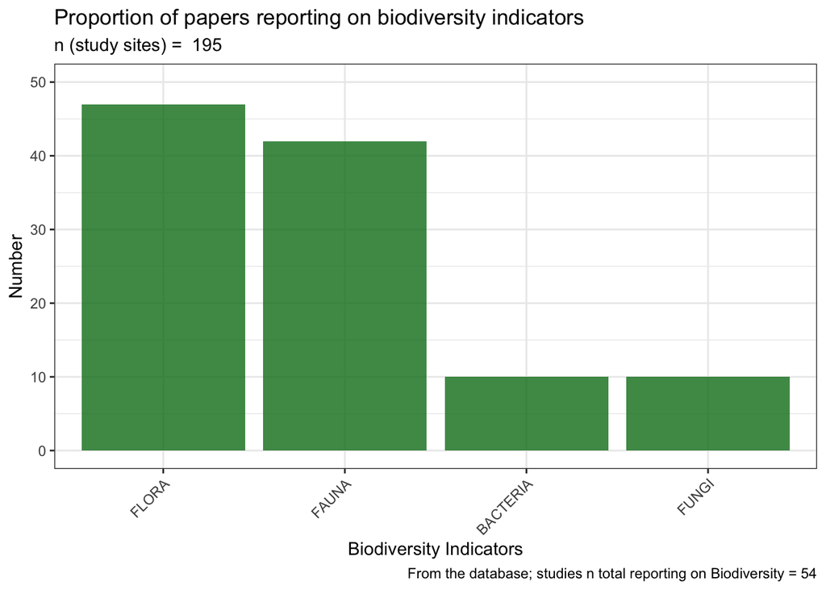

```r
total_n_BD <- biodiversity.sum.data %>%
  filter(key == "BD")

biodiversity.plot.data %>%
ggplot(aes(x = reorder(BD.GROUPS, -count),
           y = count)) +
geom_bar(stat = "identity",
         fill = my_col_single,
         alpha = 0.8) +
  theme_bw() +
  ylim(c(0, 50)) +
  theme(axis.text.x = element_text(angle = 45, hjust = 1), legend.position = "none")  +
 # geom_text(aes(label = paste0(round(pct*100, 1), "%")), size = 3, vjust = -2) +
  labs(title = "Proportion of papers reporting on biodiversity indicators",
       subtitle = paste("n (study sites) = ", n_individual_study_sites),
       caption = paste0("From the database; studies n total reporting on Biodiversity = ", total_n_BD$value),
       x = "Biodiversity Indicators",
       y = "Number")
```

**Ecosystem Services indicators - distribution and abundance**

*Preparing dataset*

```r
ecosystem.data <-
  database %>%
  filter(INCLUDED == TRUE) %>%
  # selecting Ecosystem services columns
  select(ID.P, ID.S, #ST.TYPE, MANAGEMENT
         starts_with("ES")) %>%
  mutate(across(matches("ES"), as.logical)) %>%
  mutate_all(~replace_na(., 0)) %>%                   # <- Including NA's as 0 (FALSE)
  mutate_if(is.logical, as.numeric) %>%

  rename("Food (yield)" = ES.SUB.PROV.FOOD,
         "Feed" =  ES.SUB.PROV.FEED,
         "Fibre" = ES.SUB.PROV.FIBRE,
         "Fuel (firewood etc.)" = ES.SUB.PROV.FUEL,
         "Genetic resources" = ES.SUB.PROV.GENRES,
         "Biochemicals" = ES.SUB.PROV.BIOCHEM,
         "Ornamentals" = ES.SUB.PROV.ORNA,
         "Fresh water" = ES.SUB.PROV.WATFRESH,

         "Air regulation" = ES.SUB.REGU.AIR,
         "Climate regulation" = ES.SUB.REGU.CLIMREG,
         "Carbon sequestration" = ES.SUB.REGU.CSEQREG,
         "Water regulation" = ES.SUB.REGU.WATREG,
         "Erosion regulation" = ES.SUB.REGU.EROREG,
         "Water purification" = ES.SUB.REGU.WATPUR,
         "Disease regulation" = ES.SUB.REGU.DISREG,
         "Pest regulation" = ES.SUB.REGU.PESTREG,
         "Polination regulation" = ES.SUB.REGU.POLREG,
         "Natural hazards regulation" = ES.SUB.REGU.NATHAZREG,

         "Soil formation" = ES.SUB.SUPP.SOILFORM,
         "Photosynthesis" = ES.SUB.SUPP.PHOTSYNT,
         "Primary production" = ES.SUB.SUPP.PRIMPROD,
         "Nutrient cycling" = ES.SUB.SUPP.NUTRICYC,
         "Water cycling" = ES.SUB.SUPP.WATCYC,

         "Cultural diversity" = ES.SUB.CULT.CULTDIV,
         "Spiritual value" = ES.SUB.CULT.SPIRITVAL,
         "Knowledge systems" = ES.SUB.CULT.KNOWLSYS,
         "Educational value" = ES.SUB.CULT.EDUVAL,
         "Inspirational value" = ES.SUB.CULT.INSPIR,
         "Aesthetic value" = ES.SUB.CULT.AESTVAL,
         "Social relations" = ES.SUB.CULT.SOCREL,
         "Sense of place" = ES.SUB.CULT.SENPLACE,
         "Cultural heritage value" = ES.SUB.CULT.CULTHERIVAL,
         "Recreational and ecotourism" = ES.SUB.CULT.RECRECOTOUR,

         "Provisioning ES" = ES.PROV,
         "Regulating ES" = ES.REGU,
         "Supporting ES" = ES.SUPP,
         "Cultural ES" = ES.CULT,
         "Ecosystem Services" = ES)


# sum the data using apply & use this for beautiful barplot

ecosystem.sum.data <-
  data.frame(value = apply(ecosystem.data, MARGIN = 2, FUN = sum))


ecosystem.sum.data$key = rownames(ecosystem.sum.data)

ecosystem.plot.data <-
ecosystem.sum.data %>%
  rename(count = value,
         ES.INDICATORS =  key) %>%
  filter(ES.INDICATORS == "Provisioning ES" |
         ES.INDICATORS == "Regulating ES" |
         ES.INDICATORS == "Supporting ES" |
         ES.INDICATORS == "Cultural ES") %>%
  # grouping, counting and preparing groups for plotting
  group_by(ES.INDICATORS) %>%
  summarise(count = sum(count)) %>%
  mutate(pct = (count/sum(count))) %>%
  arrange(desc(-count))

ecosystem.plot.data
```

```
## # A tibble: 4 × 3
##   ES.INDICATORS   count    pct
##   <chr>           <dbl>  <dbl>
## 1 Cultural ES        15 0.0448
## 2 Regulating ES      89 0.266
## 3 Supporting ES     105 0.313
## 4 Provisioning ES   126 0.376
```

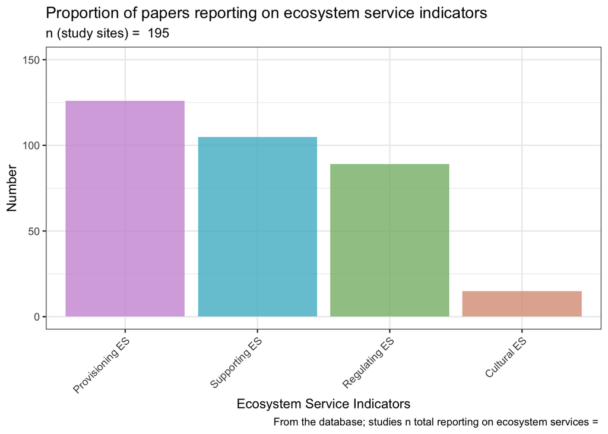

```r
total_n_ES <- ecosystem.sum.data %>%
  filter(key == "ES")

ecosystem.plot.broad <-
ecosystem.plot.data %>%
ggplot(aes(x = reorder(ES.INDICATORS, -count),
           y = count,
           fill = ES.INDICATORS)) +
geom_bar(stat = "identity",
         fill = my_cols_pal_four,
         alpha = 0.8) +
  theme_bw() +
  ylim(c(0, 150)) +
  theme(axis.text.x = element_text(angle = 45, hjust = 1), legend.position = "none")  +
  #geom_text(aes(label = paste0(round(pct*100, 1), "%")), size = 3, vjust = -2) +
  labs(title = "Proportion of papers reporting on ecosystem service indicators",
       subtitle = paste("n (study sites) = ", n_individual_study_sites),
       caption = paste0("From the database; studies n total reporting on ecosystem services = ", total_n_ES$value),
       x = "Ecosystem Service Indicators",
       y = "Number")

ecosystem.plot.broad
```

Provision

```r
ecosystem.prov.plot.data <-
ecosystem.sum.data %>%
  rename(count = value,
         ES.INDICATORS =  key) %>%
  pivot_wider(names_from = ES.INDICATORS, values_from = count) %>%
  select("Food (yield)",
         "Feed",
         "Fibre",
         "Fuel (firewood etc.)",
         "Genetic resources",
         "Biochemicals",
         "Ornamentals",
         "Fresh water") %>%
  pivot_longer(cols = everything(),
               names_to = "ES.SUB.PROV.INDICATORS",
               values_to = "count") %>%
  # grouping, counting and preparing groups for plotting
  group_by(ES.SUB.PROV.INDICATORS) %>%
  summarise(count = sum(count)) %>%
  mutate(pct = (count/sum(count))) %>%
  arrange(desc(-count))
```

```r
ecosystem.prov.plot <-
ecosystem.prov.plot.data %>%
ggplot(aes(x = reorder(ES.SUB.PROV.INDICATORS, -count),
           y = count,
           fill = ES.SUB.PROV.INDICATORS)) +
geom_bar(stat = "identity",
         fill = my_cols_pal_four[4],
         alpha = 0.8) +
  theme_bw() +
  ylim(c(0, 120)) +
  theme(axis.text.x = element_text(angle = 45, hjust = 1), legend.position = "none",
        axis.title.x=element_blank(), axis.title.y=element_blank(),
        plot.margin = margin(l = 0 + margin_spacer(ecosystem.prov.plot.data$ES.SUB.PROV.INDICATORS)))  +
  #geom_text(aes(label = paste0(round(pct*100, 1), "%")), size = 3, vjust = -2) +
  labs(title = "Provisioning ES",
       subtitle = paste("n (study sites) = ", n_individual_study_sites))
```

Supporting

```r
ecosystem.supp.plot.data <-
ecosystem.sum.data %>%
  rename(count = value,
         ES.INDICATORS =  key) %>%
  pivot_wider(names_from = ES.INDICATORS, values_from = count) %>%
  select("Air regulation",
         "Climate regulation",
         "Carbon sequestration",
         "Water regulation",
         "Erosion regulation",
         "Water purification",
         "Disease regulation",
         "Pest regulation",
         "Polination regulation",
         "Natural hazards regulation") %>%
  pivot_longer(cols = everything(),
               names_to = "ES.SUB.SUPP.INDICATORS",
               values_to = "count") %>%
  # grouping, counting and preparing groups for plotting
  group_by(ES.SUB.SUPP.INDICATORS) %>%
  summarise(count = sum(count)) %>%
  mutate(pct = (count/sum(count))) %>%
  arrange(desc(-count))
```

```r
ecosystem.supp.plot <-
ecosystem.supp.plot.data %>%
ggplot(aes(x = reorder(ES.SUB.SUPP.INDICATORS, -count),
           y = count,
           fill = ES.SUB.SUPP.INDICATORS)) +
geom_bar(stat = "identity",
         fill = my_cols_pal_four[3],
         alpha = 0.8) +
  theme_bw() +
  ylim(c(0, 120)) +
  theme(axis.text.x = element_text(angle = 45, hjust = 1), legend.position = "none",
        axis.title.x=element_blank(), axis.title.y=element_blank(),
        plot.margin = margin(l = 0 + margin_spacer(ecosystem.supp.plot.data$ES.SUB.SUPP.INDICATORS)))  +
  #geom_text(aes(label = paste0(round(pct*100, 1), "%")), size = 3, vjust = -2) +
  labs(title = "Supporting ES",
       subtitle = paste("n (study sites) = ", n_individual_study_sites))
```

Regulating

```r
ecosystem.regu.plot.data <-
ecosystem.sum.data %>%
  rename(count = value,
         ES.INDICATORS =  key) %>%
  pivot_wider(names_from = ES.INDICATORS, values_from = count) %>%
  select("Soil formation",
         "Photosynthesis",
         "Primary production",
         "Nutrient cycling",
         "Water cycling") %>%
  pivot_longer(cols = everything(),
               names_to = "ES.SUB.REGU.INDICATORS",
               values_to = "count") %>%
    # grouping, counting and preparing groups for plotting
  group_by(ES.SUB.REGU.INDICATORS) %>%
  summarise(count = sum(count)) %>%
  mutate(pct = (count/sum(count))) %>%
  arrange(desc(-count))
```

```r
ecosystem.regu.plot <-
ecosystem.regu.plot.data %>%
ggplot(aes(x = reorder(ES.SUB.REGU.INDICATORS, -count),
           y = count,
           fill = ES.SUB.REGU.INDICATORS)) +
geom_bar(stat = "identity",
         fill = my_cols_pal_four[2],
         alpha = 0.8) +
  theme_bw() +
  ylim(c(0, 120)) +
  theme(axis.text.x = element_text(angle = 45, hjust = 1), legend.position = "none",
        axis.title.x=element_blank(), axis.title.y=element_blank(),
        plot.margin = margin(l = 0 + margin_spacer(ecosystem.regu.plot.data$ES.SUB.REGU.INDICATORS)))  +
  #geom_text(aes(label = paste0(round(pct*100, 1), "%")), size = 3, vjust = -2) +
  labs(title = "Regulating ES",
       subtitle = paste("n (study sites) = ", n_individual_study_sites))
```

Cultural

```r
ecosystem.cult.plot.data <-
ecosystem.sum.data %>%
  rename(count = value,
         ES.INDICATORS =  key) %>%
  pivot_wider(names_from = ES.INDICATORS, values_from = count) %>%
  select("Cultural diversity",
         "Spiritual value",
         "Knowledge systems",
         "Educational value",
         "Inspirational value",
         "Aesthetic value",
         "Social relations",
         "Sense of place",
         "Cultural heritage value",
         "Recreational and ecotourism") %>%
  pivot_longer(cols = everything(),
               names_to = "ES.SUB.CULT.INDICATORS",
               values_to = "count") %>%
    # grouping, counting and preparing groups for plotting
  group_by(ES.SUB.CULT.INDICATORS) %>%
  summarise(count = sum(count)) %>%
  mutate(pct = (count/sum(count))) %>%
  arrange(desc(-count))
```

```r
ecosystem.cult.plot <-
ecosystem.cult.plot.data %>%
ggplot(aes(x = reorder(ES.SUB.CULT.INDICATORS, -count),
           y = count,
           fill = ES.SUB.CULT.INDICATORS)) +
geom_bar(stat = "identity",
         fill = my_cols_pal_four[1],
         alpha = 0.8) +
  theme_bw() +
  ylim(c(0, 120)) +
  theme(axis.text.x = element_text(angle = 45, hjust = 1), legend.position = "none",
        axis.title.x=element_blank(), axis.title.y=element_blank(),
        plot.margin = margin(l = 0 + margin_spacer(ecosystem.cult.plot.data$ES.SUB.CULT.INDICATORS)))  +
  #geom_text(aes(label = paste0(round(pct*100, 1), "%")), size = 3, vjust = -2) +
  labs(title = "Cultural ES",
       subtitle = paste("n (study sites) = ", n_individual_study_sites))
```

Collecting in cowplot

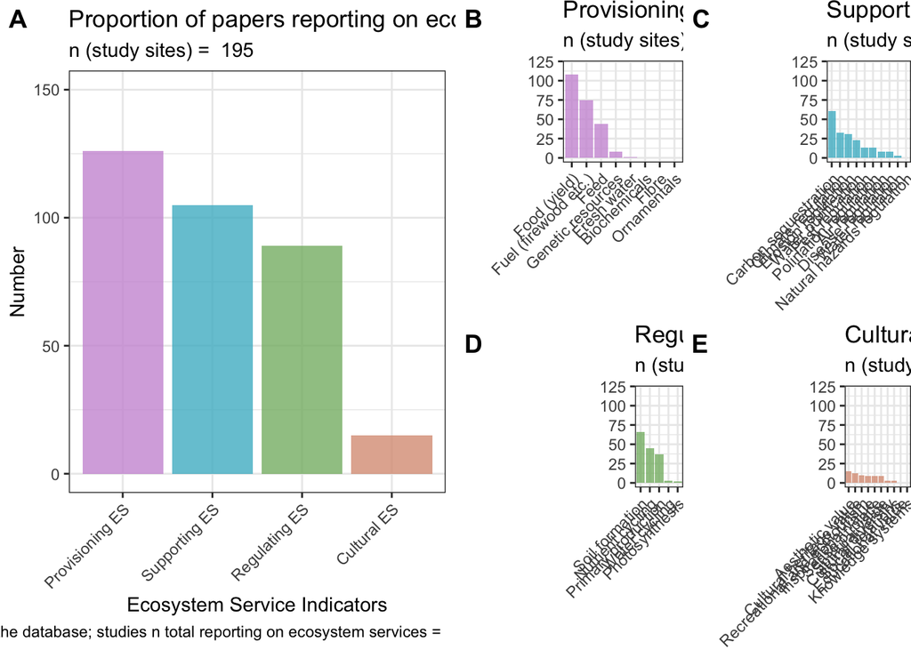

```r
# ecosystem.plot <- list(ecosystem.prov.plot, ecosystem.supp.plot, ecosystem.regu.plot, ecosystem.cult.plot)
# plot_grid(plotlist = ecosystem.plot,
#           ncol = 2, align = 'v')
#
# ecosystem.plot.all <- list(ecosystem.prov.plot,
#                            ecosystem.supp.plot,
#                            ecosystem.regu.plot,
#                            ecosystem.cult.plot)

side_col <- plot_grid(ecosystem.prov.plot,
                        ecosystem.supp.plot,
                        ecosystem.regu.plot,
                        ecosystem.cult.plot,
                        labels = c("B", "C", "D", "E"),
                        align = 'h')

plot_grid(ecosystem.plot.broad, side_col,
          ncol = 2,
          nrow = 1,
          labels = c("A", ""),
          rel_heights = c(1.2, 1))
```

**Categories of approach - distribution and abundance**

*Preparing dataset*

```r
categories.data <-
  database %>%
  filter(INCLUDED == TRUE) %>%
  # selecting Ecosystem services columns
  select(ID.P, ID.S, #ST.TYPE, MANAGEMENT
         starts_with("CAT")) %>%
  mutate(across(matches("CAT"), as.logical)) %>%
  mutate_all(~replace_na(., 0)) %>%                   # <- Including NA's as 0 (FALSE)
  mutate_if(is.logical, as.numeric)
```

### Matrices

**Biodiversity - Crops**